# Base 6: Graphiques basiques

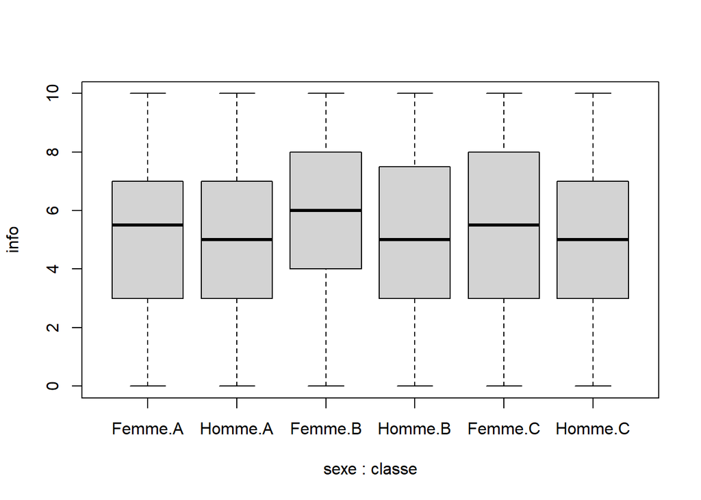

```r
# Les notes d'informatique selon le sexe et la classe
boxplot(info~sexe*classe)
```

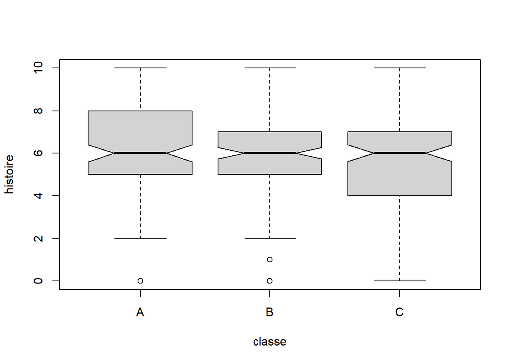

```r
# Les notes d'histoire selon la classe avec l'option notch
boxplot(histoire~classe, notch=TRUE)
```

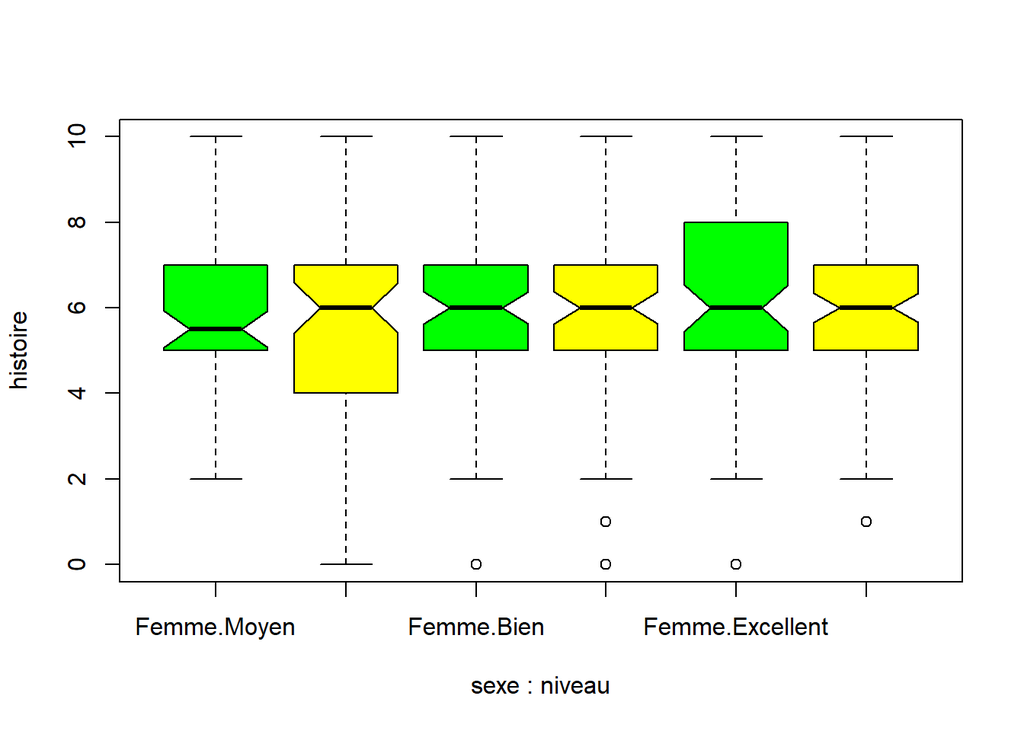

```r
# les notes d'histoire selin le sexe et le niveau avec l'option notch et les couleurs vert et jaune.
boxplot(histoire~sexe*niveau, notch=TRUE,col=c("green","yellow"))
```

Pour plus d’informations, vous pouvez consulter le site suivant:

https://www.statmethods.net/graphs/creating.html

Nous n’avons pas passé beaucoup de temps sur ce tuto, car il existe des packages bien plus joli et performant pour faire des graphiques comme nous l’avions dit plus tôt, ggplot2 (et ploty). Nous avons présenté les graphiques précédents parce qu’ils permettent d’avoir des informations rapides, mais vous préférerez probablement les autres packages pour vos présentations et travaux.

Ce tuto est terminé.